# ICE and S&E PhDs

Alternative title + sign from the rally at the MA State House today: Melt the ICE

# intro

This project is motivated by recent (Monday 7/6) ICE news [here.](https://www.ice.gov/news/releases/sevp-modifies-temporary-exemptions-nonimmigrant-students-taking-online-courses-during)

The NSF puts out data on doctoral degree earners and their citizenship – the most recent data covers 2006-2016. See table 7-4 [here](https://ncses.nsf.gov/pubs/nsf19304/data).

I use this data to show summary stats, and graphs related to the prevalence of international students (temporary residents in the NSF) in S&E PhD programs.

# prep/clean

The NSF data is not in a natural shape for me to plot it. So, first things first. I need to clean it up.[^1] I just care about the permanent resident/US citizen and temporary resident dichotomy for now.

```r
library(tidyverse);library(readxl)
nsf<-read_xlsx("degrees_nsf.xlsx")
```

```
* `` -> ...2
* `` -> ...3
* `` -> ...4
* `` -> ...5
* `` -> ...6
* ...
```

```r
#remove unneeded rows
nsf1<-nsf%>%
  slice(-(1:2))%>%
  filter(`Table 7-4`!="Hispanic or Latinoa" &
           `Table 7-4`!="Non-Hispanic or Latino" &
           `Table 7-4`!="American Indian or Alaska Native" &
           `Table 7-4`!="Asian" &
           `Table 7-4`!="Asian or Pacific Islanderb" &
           `Table 7-4`!="Black or African American" &
           `Table 7-4`!="Native Hawaiian or Other Pacific Islander" &
           `Table 7-4`!="White" &
           `Table 7-4`!="More than one racec" &
           `Table 7-4`!="Other or unknown race and ethnicity")

names(nsf1)<-nsf1[1,]
```

```
The `value` argument of ``names<-`()` must be a character vector as of tibble 3.0.0.
```

```r
nsf1<-nsf1[-1,]

types<-nsf1%>%
  filter(`Field, citizenship, ethnicity, and race`!="U.S. citizen and permanent resident" &
          `Field, citizenship, ethnicity, and race`!="Temporary resident")%>%
  select(`Field, citizenship, ethnicity, and race`)%>%
  mutate(order=row_number())

types3<-types%>%
  bind_rows(types)%>%
  bind_rows(types)%>%
  arrange(order)

nsf2<-nsf1%>%
  bind_cols(types3)%>%select(-order)%>%
  rename(citizen=`Field, citizenship, ethnicity, and race`)%>%
  rename(type=`Field, citizenship, ethnicity, and race1`)%>%
  filter(citizen=="U.S. citizen and permanent resident" | citizen=="Temporary resident")

nsf_long<-nsf2%>%
  pivot_longer(cols = starts_with("2"),
               names_to = "year")%>%
  mutate(value1=as.double(value))%>%
  filter(type!="Other")
```

# summary stats

What % of all doctoral degree recipients are temporary residents?

```r
nsf_long%>%
  filter(type=="All degrees")%>%
  group_by(citizen)%>%
  summarise(n=sum(value1))
```

| citizen | n |
| --- | --- |
| Temporary resident | 188492 |
| U.S. citizen and permanent resident | 503012 |

```r
188492/(188492+503012)
```

```
[1] 0.2725827
```

What % of S+E doctoral degree recipients are temporary residents?

```r
nsf_long%>%
  filter(type=="All S&E")%>%
  group_by(citizen)%>%
  summarise(n=sum(value1))
```

| citizen | n |
| --- | --- |
| Temporary resident | 145999 |
| U.S. citizen and permanent resident | 239995 |

```r
145999/(145999+239995)
```

```
[1] 0.3782416
```

Economics?

```r
nsf_long%>%
  filter(type=="Economics")%>%
  group_by(citizen)%>%
  summarise(n=sum(value1))
```

| citizen | n |
| --- | --- |
| Temporary resident | 7894 |
| U.S. citizen and permanent resident | 5177 |

```r
7894/(7894+5177)
```

```
[1] 0.6039324
```

# Graph for raw counts by citizenship and field

[figure not shown]

```r
# select most detailed field
nsf_long_fields<-nsf_long%>%
  filter(type!="All degrees" &
           type!="All S&E" &type!="Non-S&E" &
           type!="Science" &
           type!="Engineering" &
           type!="Earth, atmospheric, and ocean sciences" &
           type!="Physical sciences" &
           type!="Social sciences")%>%
  mutate(type=replace(type, type=="Political science and public administration",
                      "Poli sci & public admin"))%>%
  mutate(type=replace(type, type=="Mathematics and statistics",
                      "Mathematics & statistics"))%>%
  mutate(type=replace(type, type=="Ethnic and area studies",
                      "Ethnic & area studies"))%>%
  mutate(citizen=replace(citizen, citizen=="U.S. citizen and permanent resident",
                      "U.S. citizen or permanent resident"))

ggplot(data=nsf_long_fields, aes(x=year, y=value1, fill=citizen, group=citizen)) +
  theme_minimal()+ theme(text=element_text(family="Palatino", size=13),
                         plot.title.position = "plot",
                         legend.position = "top",
                         plot.title = element_text(size=20),
                         axis.title.y = element_text(size=15))+
  geom_area(aes(fill=citizen), position='stack')+
  scale_fill_manual(values = c("#009E73", "#999999"), name="Citizenship") +
  facet_wrap(~type, scales="free")+ expand_limits(y = 0)+
  scale_x_discrete(labels = c("'06", "", "'08", "", "'10", "", "'12", "", "'14", "", "'16"))+
  labs(x="", y="Number of Doctoral Degrees Awarded", caption="Viz by Alex Albright")+
  ggtitle("How Many Science & Engineering Doctoral Degree Earners are International Students?",
          subtitle= "NSF Data on PhD Degrees, 2006-2016")

ggsave("phd_count_by_citizenship.png", width=11, height=7.5, dpi=300)
```

# Graph by percent temporary resident within field

## Nightingale plot

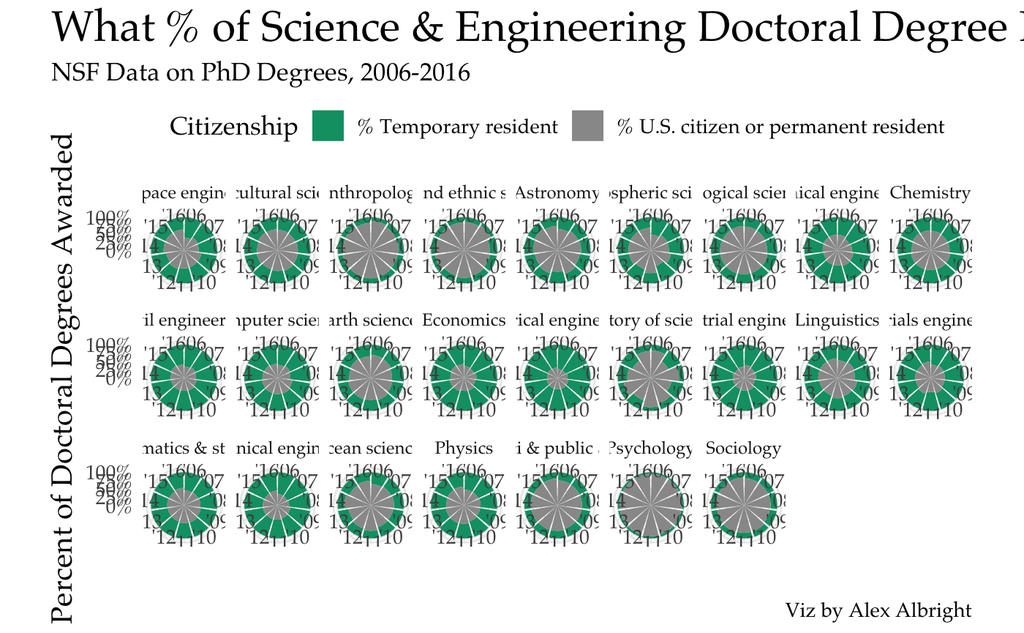

```r
nsf_long_fields1<-nsf_long_fields%>%
  group_by(year, type)%>%
  mutate(tot=sum(value1))%>%
  filter(citizen=="Temporary resident")%>%
  mutate(temp_perc=value1/tot,
         cit_perm_perc=1-temp_perc)%>%
  select(-c(value, value1, tot))%>%
  pivot_longer(cols = 4:5)%>%
  mutate(name=replace(name, name=="temp_perc",
                      "% Temporary resident"))%>%
  mutate(name=replace(name, name=="cit_perm_perc",
                      "% U.S. citizen or permanent resident"))

ggplot(data=nsf_long_fields1, aes(x=year, y=value, fill=name, group=name)) +
  theme_minimal()+ theme(text=element_text(family="Palatino", size=13),
                         plot.title.position = "plot",
                         legend.position = "top",
                         plot.title = element_text(size=22),
                         strip.text = element_text(size=9),
                         axis.title.y = element_text(size=15))+
  geom_bar(stat="identity", aes(fill=name), position='stack')+
  coord_polar()+ facet_wrap(~type, nrow=3)+
  scale_fill_manual(values = c("#009E73", "#999999"), name="Citizenship") +
  scale_x_discrete(labels = c("'06", "'07", "'08", "'09", "'10",
                              "'11", "'12", "'13", "'14", "'15", "'16"))+
  scale_y_continuous(labels = scales::percent)+
  labs(x="", y="Percent of Doctoral Degrees Awarded", caption="Viz by Alex Albright")+
  ggtitle("What % of Science & Engineering Doctoral Degree Earners are International Students?",
          subtitle= "NSF Data on PhD Degrees, 2006-2016")

ggsave("phd_per_by_citizenship.png", width=13.5, height=7, dpi=300)
```

## just a simple bar chart

Color economics for emphasis.

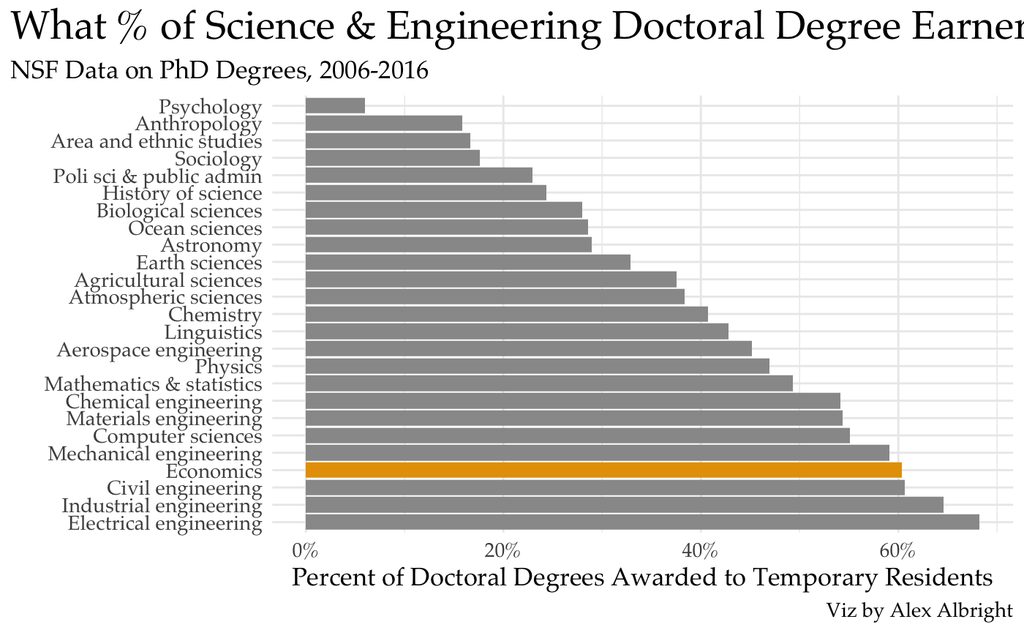

```r
field_p<-nsf_long_fields%>%
  ungroup()%>%
  group_by(type)%>%
  mutate(tot=sum(value1))%>%
  filter(citizen=="Temporary resident")%>%
  mutate(temp=sum(value1))%>%
  mutate(temp_perc=temp/tot)%>%
  select(type, temp_perc)%>% unique()%>%
  mutate(econ=if_else(type=="Economics", 1, 0))

ggplot(data=field_p, aes(x=reorder(type, -temp_perc),
                         y=temp_perc, fill=factor(econ), group=factor(econ))) +
  theme_minimal()+ theme(text=element_text(family="Palatino", size=13),
                         legend.position = "none", plot.title.position = "plot",
                         plot.title = element_text(size=20.5),
                         strip.text = element_text(size=9),
                         axis.title.y = element_text(size=15))+
  geom_bar(stat="identity")+ coord_flip()+
  scale_fill_manual(values = c("#999999", "#E69F00")) +
  scale_y_continuous(labels = scales::percent)+
  labs(x="", y="Percent of Doctoral Degrees Awarded to Temporary Residents",
       caption="Viz by Alex Albright")+
  ggtitle("What % of Science & Engineering Doctoral Degree Earners are International Students?",
          subtitle= "NSF Data on PhD Degrees, 2006-2016")

ggsave("phd_per_temp.png", width=11, height=8, dpi=300)
```

# diagram for how NSF categorizes things

See [here](https://ncses.nsf.gov/pubs/nsf19304/data) for source. More on the `DiagrammeR` package [here.](https://mikeyharper.uk/flowcharts-in-r-using-diagrammer/)

```r
library(DiagrammeR)
library(DiagrammeRsvg)
library(magrittr)
library(rsvg)

graph<-"digraph  {
      graph [layout = dot, rankdir = LR]
      # node definitions with substituted label text
      node [fontname = Palatino, shape = rectangle]
      tab1 [label = '@@1']

      tab2 [label = '@@2']
      tab3 [label = '@@3']

      tab4 [label = '@@4']
      tab5 [label = '@@5']

      tab6 [label = '@@6']
      tab7 [label = '@@7']
      tab8 [label = '@@8']
      tab9 [label = '@@9']
      tab10 [label = '@@10']
      tab11 [label = '@@11']
      tab12 [label = '@@12']
      tab13 [label = '@@13']

      tab14 [label = '@@14']
      tab15 [label = '@@15']
      tab16 [label = '@@16']
      tab17 [label = '@@17']
      tab18 [label = '@@18']
      tab19 [label = '@@19']
      tab20 [label = '@@20']
      tab21 [label = '@@21']

      tab22 [label = '@@22']
      tab23 [label = '@@23']
      tab24 [label = '@@24']

      tab25 [label = '@@25']
      tab26 [label = '@@26']
      tab27 [label = '@@27']
      tab28 [label = '@@28']

      tab29 [label = '@@29']
      tab30 [label = '@@30']
      tab31 [label = '@@31']
      tab32 [label = '@@32']
      tab33 [label = '@@33']
      tab34 [label = '@@34']
      tab35 [label = '@@35']
      tab36 [label = '@@36']

      # edge definitions with the node IDs
      tab1 -> tab2;
      tab1 -> tab3;

      tab2 -> tab4;
      tab2 -> tab5;

      tab4 -> tab6;
      tab4 -> tab7;
      tab4 -> tab8;
      tab4 -> tab9;
      tab4 -> tab10;
      tab4 -> tab11;
      tab4 -> tab12;
      tab4 -> tab13;

      tab5 -> tab14;
      tab5 -> tab15;
      tab5 -> tab16;
      tab5 -> tab17;
      tab5 -> tab18;
      tab5 -> tab19;
      tab5 -> tab20;
      tab5 -> tab21;

      tab9 -> tab22;
      tab9 -> tab23;
      tab9 -> tab24;

      tab11 -> tab25;
      tab11 -> tab26;
      tab11 -> tab27;
      tab11 -> tab28;

      tab13 -> tab29;
      tab13 -> tab30;
      tab13 -> tab31;
      tab13 -> tab32;
      tab13 -> tab33;
      tab13 -> tab34;
      tab13 -> tab35;
      tab13 -> tab36;
      }

      [1]: 'All PhDs'
      [2]: 'S&E'
      [3]: 'Non-S&E'
      [4]: 'Science'
      [5]: 'Engineering'
      [6]: 'Agricultural Sciences'
      [7]: 'Biological Sciences'
      [8]: 'Computer Sciences'
      [9]: 'Earth, Atmospheric, & Ocean Sciences'
      [10]: 'Mathematics and statistics'
      [11]: 'Physical sciences'
      [12]: 'Psychology'
      [13]: 'Social sciences'
      [14]: 'Aerospace'
      [15]: 'Chemical'
      [16]: 'Civil'
      [17]: 'Electrical'
      [18]: 'Industrial'
      [19]: 'Materials'
      [20]: 'Mechanical'
      [21]: 'Other'
      [22]: 'Atmospheric sciences'
      [23]: 'Earth sciences'
      [24]: 'Ocean sciences'
      [25]: 'Astronomy'
      [26]: 'Chemistry'
      [27]: 'Physics'
      [28]: 'Other'
      [29]: 'Anthropology'
      [30]: 'Area and ethnic studies'
      [31]: 'Economics'
      [32]: 'History of science'
      [33]: 'Linguistics'
      [34]: 'Political science & public administration'
      [35]: 'Sociology'
      [36]: 'Other'
      "

grViz(graph) %>%
    export_svg %>% charToRaw %>% rsvg_png("nsf_cat.png")
```

[^1]: A [few years ago](https://thelittledataset.com/2015/12/31/this-post-is-brought-to-you-by-the-national-science-foundation/) when I used this data, I had to do it by hand because I had no idea how to clean it with code. Progress!